# Introduction to proteomics data analysis

Lieven Clement

7 October 2020

# 1 Background

This case-study is a subset of the data of the 6th study of the Clinical Proteomic Technology Assessment for Cancer (CPTAC). In this experiment, the authors spiked the Sigma Universal Protein Standard mixture 1 (UPS1) containing 48 different human proteins in a protein background of 60 ng/$\mu$L Saccharomyces cerevisiae strain BY4741. Two different spike-in concentrations were used: 6A (0.25 fmol UPS1 proteins/$\mu$L) and 6B (0.74 fmol UPS1 proteins/$\mu$L) [5]. We limited ourselves to the data of LTQ-Orbitrap W at site 56. The data were searched with MaxQuant version 1.5.2.8, and detailed search settings were described in Goeminne et al. (2016) [1]. Three replicates are available for each concentration.

We first run the default workflow. Next we compare the method to other workflows.

# 2 Data

We first import the data from peptideRaws.txt file. This is the file containing your peptideRaw-level intensities. For a MaxQuant search [6], this peptideRaws.txt file can be found by default in the “path_to_raw_files/combined/txt/” folder from the MaxQuant output, with “path_to_raw_files” the folder where the raw files were saved. In this vignette, we use a MaxQuant peptideRaws file which is a subset of the cptac study. This data is available in the `msdata` package. To import the data we use the `QFeatures` package.

We generate the object peptideRawFile with the path to the peptideRaws.txt file. Using the `grepEcols` function, we find the columns that contain the expression data of the peptideRaws in the peptideRaws.txt file.

```r
library(tidyverse)
library(limma)
library(QFeatures)
library(msqrob2)
library(BiocParallel)

peptidesFile <- msdata::quant(pattern = "cptac_a_b_peptides", full.names = TRUE)
ecols <- MSnbase::grepEcols(peptidesFile, "Intensity ", split = "\t")
pe <- readQFeatures(table = peptidesFile, fnames = 1, ecol = ecols,
                   name = "peptideRaw", sep="\t")
```

We can extract the spike-in condition from the raw file name.

```r
cond <- which(strsplit(colnames(pe)[[1]][1], split = "")[[1]] == "A") # find where condition is stored
colData(pe)$condition <- substr(colnames(pe), cond, cond) %>%
  unlist %>%
  as.factor
```

We calculate how many non zero intensities we have per peptide This will be useful for filtering.

```r
rowData(pe[["peptideRaw"]])$nNonZero <- rowSums(assay(pe[["peptideRaw"]]) > 0)
```

peptide with zero intensities are missing peptide and should be represent with a `NA` value rather than `0`.

```r
pe <- zeroIsNA(pe, "peptideRaw")
```

## 2.1 Data exploration

We can inspect the missingness in our data with the `plotNA()` function provided with `MSnbase`. 45% of all peptide intensities are missing and for some peptides we do not even measure a signal in any sample. The missingness is similar across samples.

```r
MSnbase::plotNA(assay(pe[["peptideRaw"]]))  +
  xlab("Peptide index (ordered by data completeness)")
```

[output not shown]

# 3 Preprocessing

This section preforms standard preprocessing for the peptide data. This include log transformation, filtering and summarisation of the data.

## 3.1 Log transform the data

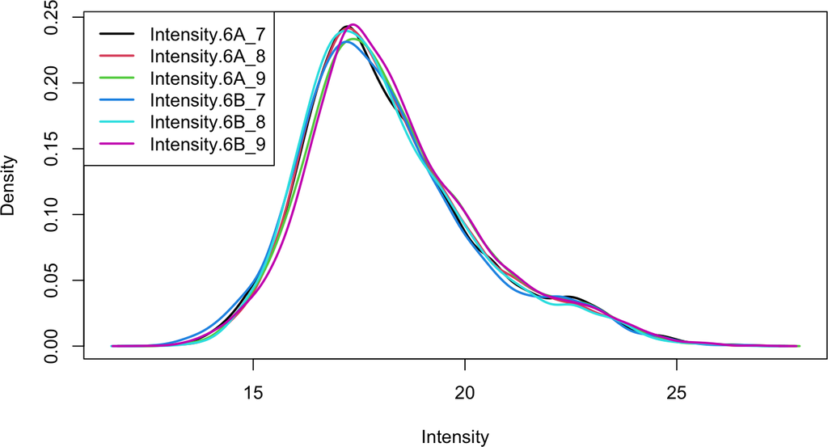

```r
pe <- logTransform(pe, base = 2,i="peptideRaw",name="peptideLog")
limma::plotDensities(assay(pe[["peptideLog"]]))
```

## 3.2 Filtering

### 3.2.1 Handling overlapping protein groups

In our approach a peptide can map to multiple proteins, as long as there is none of these proteins present in a smaller subgroup.

```r
pe[["peptideLog"]] <- pe[["peptideLog"]][rowData(pe[["peptideLog"]])$Proteins %in%
                                           smallestUniqueGroups(rowData(pe[["peptideLog"]])$Proteins), ]
```

### 3.2.2 Remove reverse sequences (decoys) and contaminants

```r
pe[["peptideLog"]] <- pe[["peptideLog"]][rowData(pe[["peptideLog"]])$Reverse != "+", ]
pe[["peptideLog"]] <- pe[["peptideLog"]][rowData(pe[["peptideLog"]])$
Potential.contaminant != "+", ]
```

### 3.2.3 Remove peptides of proteins that were only identified with modified peptides

I will skip this step for the moment. Large protein groups file needed for this.

### 3.2.4 Drop peptides that were only identified in one sample

We want to keep peptides that were at least observed twice.

```r
pe[["peptideLog"]] <- pe[["peptideLog"]][rowData(pe[["peptideLog"]])$nNonZero >= 2, ]
nrow(pe[["peptideLog"]])
```

```
## [1] 7011
```

We keep 7011 peptides upon filtering.

## 3.3 Quantile normalize the data

```r
pe <- normalize(pe, i = "peptideLog", method = "quantiles", name = "peptideNorm")
```

## 3.4 Explore quantile normalized data

Upon normalisation the density curves for all samples coincide.

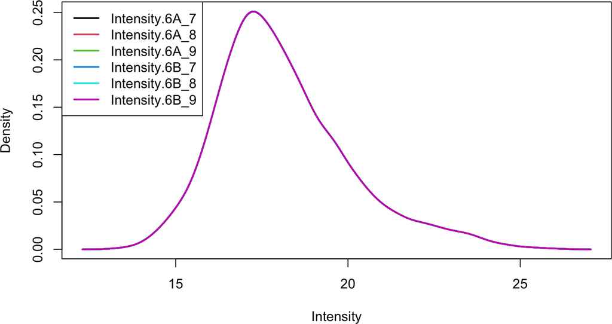

```r
limma::plotDensities(assay(pe[["peptideNorm"]]))
```

This is more clearly seen is a boxplot.

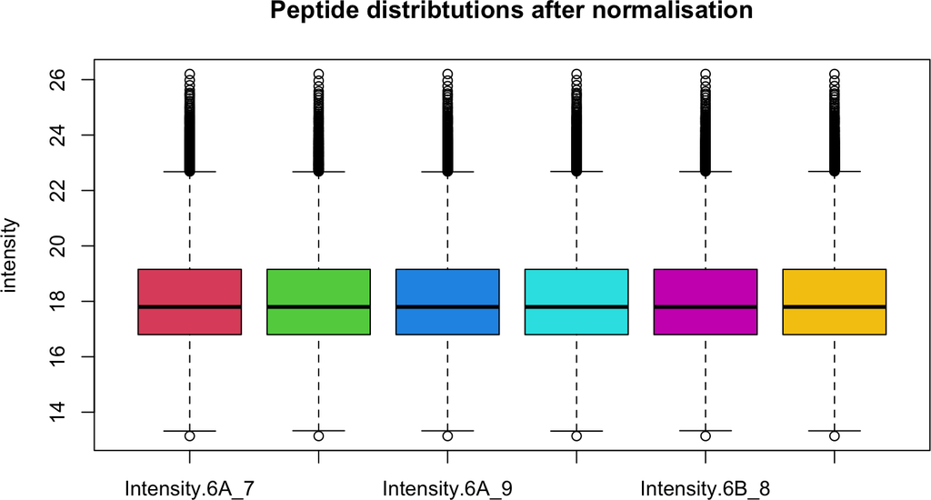

```r
boxplot(assay(pe[["peptideNorm"]]), col = palette()[-1],
        main = "Peptide distribtutions after normalisation", ylab = "intensity")
```

We can visualize our data using a Multi Dimensional Scaling plot, eg. as provided by the limma package.

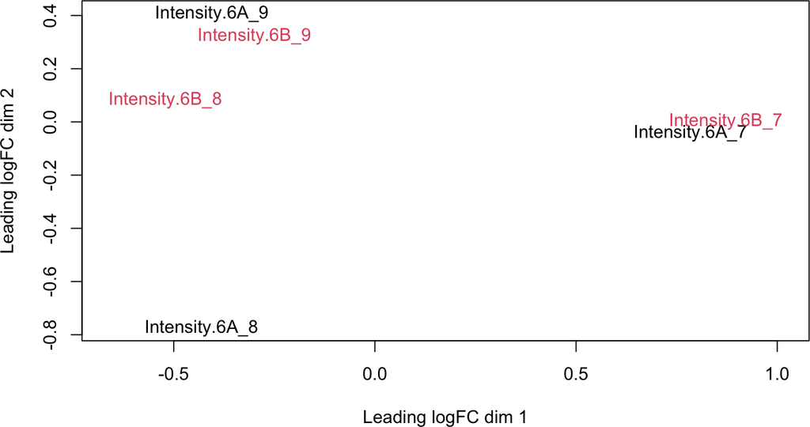

```r
limma::plotMDS(assay(pe[["peptideNorm"]]), col = as.numeric(colData(pe)$condition))
```

The first axis in the plot is showing the leading log fold changes (differences on the log scale) between the samples. We notice that the leading differences (log FC) in the peptideRaw data seems to be driven by technical variability. Indeed, the samples do not seem to be clearly separated according to the spike-in condition.

## 3.5 Summarization to protein level

We use the standard sumarisation in aggregateFeatures, which is a robust summarisation method.

```r
pe <- aggregateFeatures(pe, i = "peptideNorm", fcol = "Proteins",
                        na.rm = TRUE, name = "protein")
```

```
## Your quantitative and row data contain missing values. Please read the
## relevant section(s) in the aggregateFeatures manual page regarding the
## effects of missing values on data aggregation.
```

We notice that the leading differences (log FC) in the protein data is still according to technical variation. On the second dimension; however, we also observe a clear separation according to the spike-in condition. Hence, the summarization that accounts for peptide specific effects makes the effects due to the spike-in condition more prominent!

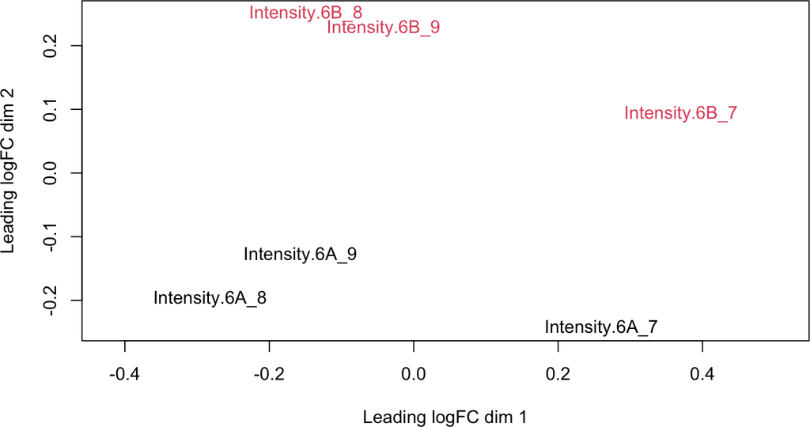

```r
plotMDS(assay(pe[["protein"]]), col = as.numeric(colData(pe)$condition))
```

# 4 Data Analysis

## 4.1 Estimation

We model the protein level expression values using msqrob. By default msqrob2 estimates the model parameters using robust regression.

```r
pe <- msqrob(object = pe,i = "protein", formula = ~condition)
```

## 4.2 Inference

First, we extract the parameter names of the model.

```r
getCoef(rowData(pe[["protein"]])$msqrobModels[[1]])
```

```
## (Intercept)  conditionB
##   15.060948    1.564747
```

Spike-in condition a is the reference class. So the mean log2 expression for samples from condition a is ‘(Intercept). The mean log2 expression for samples from condition B is’(Intercept)+conditionB’. Hence, the average log2 fold change between condition b and condition a is modelled using the parameter ‘conditionB’. Hence, we assess the contrast ‘conditionB=0’ with our statistical test.

```r
L <- makeContrast("conditionB=0", parameterNames = c("conditionB"))
pe <- hypothesisTest(object = pe, i = "protein", contrast = L)
```

## 4.3 Plots

### 4.3.1 Volcano-plot

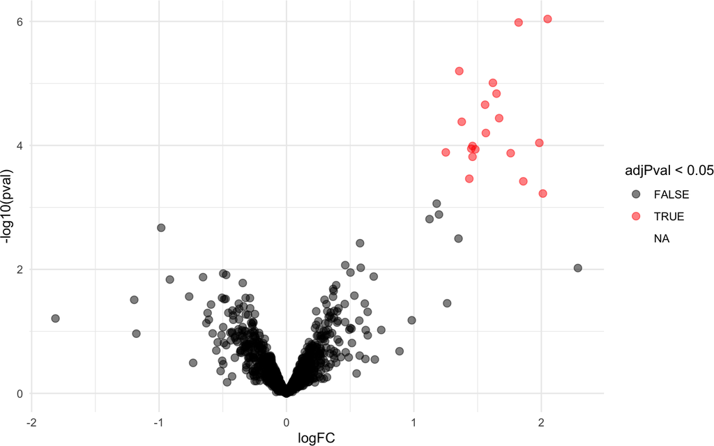

```r
volcano <- ggplot(rowData(pe[["protein"]])$conditionB,
                  aes(x = logFC, y = -log10(pval), color = adjPval < 0.05)) +
  geom_point(cex = 2.5) + scale_color_manual(values = alpha(c("black", "red"), 0.5)) + theme_minimal()
volcano
```

# 5 Comparison with other workflows

## 5.1 Median summarisation

```r
pe <- aggregateFeatures(pe, i = "peptideNorm", fcol = "Proteins", na.rm = TRUE,
                        name = "proteinMedian", fun = matrixStats::colMedians)
```

```
## Your quantitative and row data contain missing values. Please read the
## relevant section(s) in the aggregateFeatures manual page regarding the
## effects of missing values on data aggregation.
```

```r
pe <- msqrob(object = pe, i = "proteinMedian", formula = ~condition)
```

[output not shown]

[output cut: 1738 more lines]

[output not shown]

```r
pe <- hypothesisTest(object = pe, i = "proteinMedian", contrast = L)
```

### 5.1.1 MDS plot

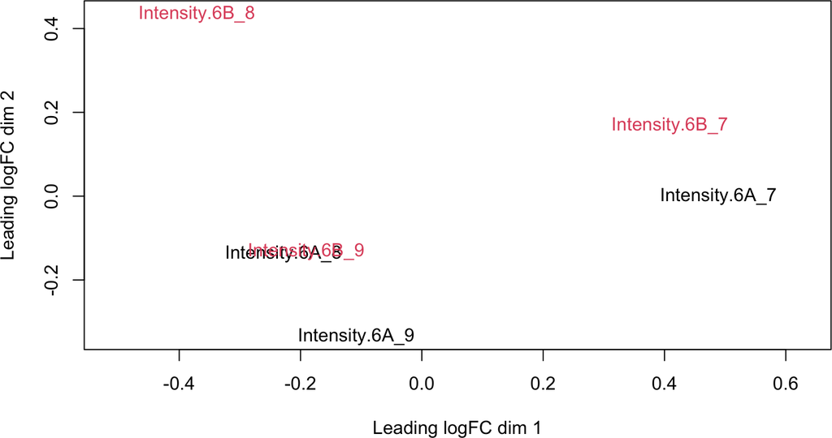

```r
limma::plotMDS(assay(pe[["proteinMedian"]]),
               col = as.numeric(colData(pe)$condition))
```

Note, that upon median summarisation the separation between the samples according to the spike-in condition is much less clear than when using robust summarisation. This is because median summarisation does not account for a differences in observed peptides per protein. Indeed, for DE proteins more peptides will go missing in the low spike-in condition a.

### 5.1.2 Volcano-plots

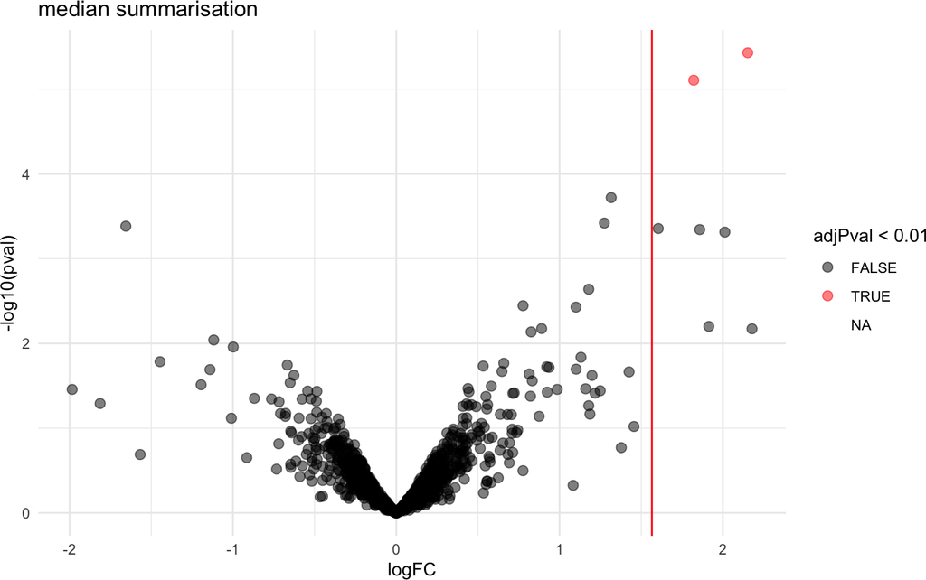

```r
volcanoMed <- rowData(pe[["proteinMedian"]])[[colnames(L)]] %>%
    ggplot(aes(x = logFC, y = -log10(pval), color = adjPval < 0.01)) +
    geom_point(cex = 2.5) +
    scale_color_manual(values = alpha(c("black", "red"), 0.5)) + theme_minimal() +
    geom_vline(xintercept = log2(0.74/.25),col="red") +
    ggtitle("median summarisation")
volcanoMed
```

Note, that less proteins are found to be DE upon median summarisation. It is indeed important that the summarisation accounts for properties of the different peptides of a protein that are present in the different samples.

## 5.2 Robust summarisation followed by robust ridge regression

msqrob2 can also be used to adopt parameter estimation using robust ridge regression by setting the argument ‘ridge=TRUE’. The performance of ridge regression generally improves for more complex designs with multiple conditions.

Note, that the parameter names for ridge regression always start with the string “ridge”.

```r
try(pe <- msqrob(object = pe,i = "protein", formula = ~condition,
                 modelColumnName = "ridge", ridge = TRUE)) # note: intentional error
```

```
## Error in msqrobLmer(y = assay(object[[i]]), formula = formula, data = colData(object),  :
##   Error: the mean model must have more than two parameters for ridge regression.
##               if you really want to adopt ridge regression when your factor has only two levels
##               rerun the function with a formula where you drop the intercept. e.g. ~-1+condition
##
```

Note, that by default ridge regression does not work for two group comparisons because it typically performs better the more parameters there are in the mean model (more complex designs). However, we can force ridge regression in a two group comparison using a formula without intercept.

```r
pe <- msqrob(object = pe, i = "protein", formula = ~-1 + condition,
             modelColumnName = "ridge", ridge = TRUE)
Lridge <- makeContrast("ridgeconditionB - ridgeconditionA = 0",
                       c("ridgeconditionB", "ridgeconditionA"))
pe <- hypothesisTest(object = pe , i = "protein", contrast = Lridge,
                      modelColumn = "ridge")
```

### 5.2.1 Volcano-plot

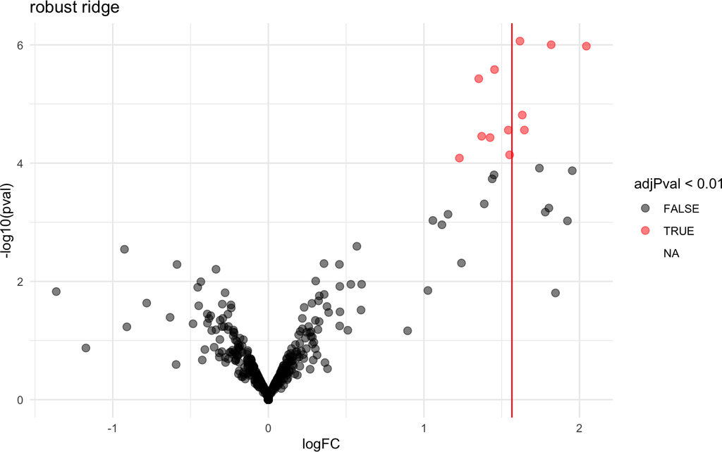

```r
volcanoRidge <- rowData(pe[["protein"]])[[colnames(Lridge)]] %>%
    ggplot(aes(x = logFC, y = -log10(pval),
           color = adjPval < 0.01)) +
    geom_point(cex = 2.5) +
    scale_color_manual(values = alpha(c("black", "red"), 0.5)) + theme_minimal() +
    geom_vline(xintercept = log2(0.74/0.25), col = "red") +
    ggtitle(paste("robust ridge"))
volcanoRidge
```

Note, that the volcano plot opens up and that the dots are more tight. The DE proteins are also around the real fold change of the spiked proteins.

# 6 Comparison of performance

Because we are analysing a spike-in study we know the ground truth, i.e. we know that only the spike-in proteins (UPS proteins) are differentially expressed.

We first add the ground truth data to the rowData of the object.

```r
rowData(pe[["protein"]])$ups <- grepl("UPS", rownames(pe[["protein"]]))
rowData(pe[["proteinMedian"]])$ups <- grepl("UPS", rownames(pe[["proteinMedian"]]))
```

## 6.1 log2 Fold Change Estimation

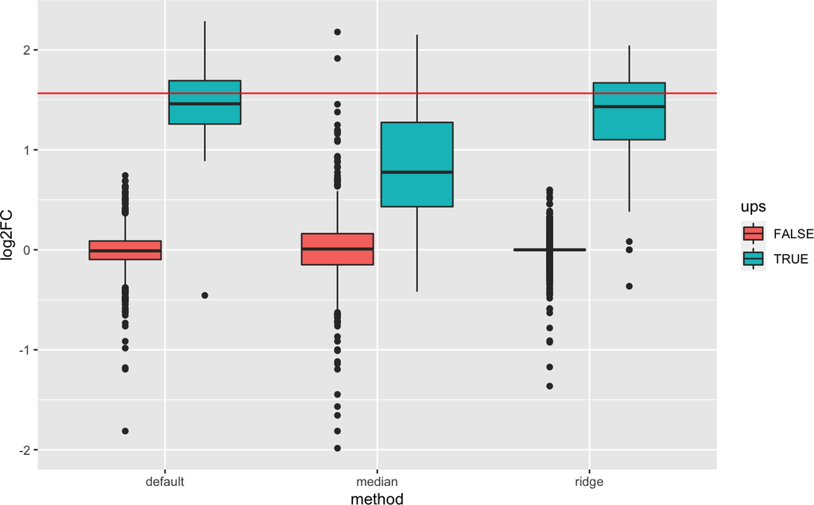

```r
logFC <- data.frame(default = rowData(pe[["protein"]])[[colnames(L)]][, 1],
                    median = rowData(pe[["proteinMedian"]])[[colnames(L)]][, 1],
                    ridge = rowData(pe[["protein"]])[[colnames(Lridge)]][, 1],
                    ups = rowData(pe[["protein"]])$ups)

logFC <-logFC %>% gather(method, log2FC, c("default", "median", "ridge"))
logFC$ups <- as.factor(logFC$ups)
logFC %>% ggplot(aes(x = method, y = log2FC, fill = ups)) + geom_boxplot() +
  geom_hline(yintercept = log2(0.74/.25), color = "red")
```

Median summarisation returns biased fold changes for the spiked UPS proteins. This is because peptides of the ups proteins that do not fly well through the mass spec are typically missing in the low spike-in condition. Hence, the protein estimates for condition a are typically overestimated and for condition b underestimated leading to an underestimation of the fold change. The default robust summarisation uses a peptide based model to summarise the data, which estimates the protein expression value while correcting for the peptide.

## 6.2 Sensitivity FDP Plots

Because we are analysing a spike-in study we know the ground truth, i.e. we know that only the spike-in proteins (UPS proteins) are differentially expressed. We can therefore evaluate the performance of the method, i.e. we will assess - the sensitivity or true positive rate (TPR), the proportion of actual positives that are correctly identified, in the protein list that we return
$$TPR=\frac{TP}{\text{#actual positives}},$$
here TP are the true positives in the list. The TPR is thus the fraction of ups proteins that we can recall.

- false discovery proportion (FPD): fraction of false positives in the protein list that we return:
  $$FPD=\frac{FP}{FP+TP},$$
  with FP the false positives. In our case the yeast proteins that are in our list.

Instead, of only calculating that for the protein list that is returned for the chosen FDR level, we can do this for all possible FDR cutoffs so that we get an overview of the quality of the ranking of the proteins in the protein list.

Function to calculate TPR and FDP

```r
tprFdp <- function(pval, tp, adjPval){
ord <- order(pval)
return(data.frame(
  pval = pval[ord],
  adjPval = adjPval[ord],
  tpr = cumsum(tp[ord])/sum(tp),
  fdp = cumsum(!tp[ord])/1:length(tp)))
}
```

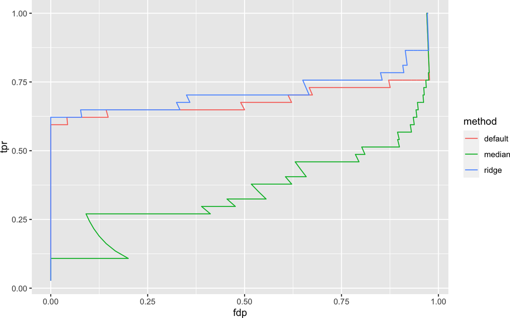

```r
tprFdpDefault <- tprFdp(rowData(pe[["protein"]])[[colnames(L)]]$pval,
             rowData(pe[["protein"]])$ups,
             rowData(pe[["protein"]])[[colnames(L)]]$adjPval)
tprFdpMedian <- tprFdp(rowData(pe[["proteinMedian"]])[[colnames(L)]]$pval,
             rowData(pe[["proteinMedian"]])$ups,
             rowData(pe[["proteinMedian"]])[[colnames(L)]]$adjPval)

tprFdpRidge <- tprFdp(rowData(pe[["protein"]])[[colnames(Lridge)]]$pval,
             rowData(pe[["protein"]])$ups,
             rowData(pe[["protein"]])[[colnames(Lridge)]]$adjPval)

hlp <- rbind(cbind(tprFdpDefault, method = "default"),
             cbind(tprFdpMedian, method = "median"),
             cbind(tprFdpRidge, method = "ridge"))
tprFdpPlot <- hlp %>%
      ggplot(aes(x = fdp, y = tpr, color = method)) +
      geom_path()
tprFdpPlot
```

Ridge regression does not seem to improve the performance in two-group comparisons. By default the ridge regression workflow returns an error message if the model only has two fixed effect parameters, e.g. “(intercept)” and parameter “conditionB”. In the vignette of a large spike-in study with multiple spike-in conditions we illustrate the benefit of ridge regression when dealing with more complex experiments.